# Chapter 5: Data Visualization in R

### ggplot2

**ggplot2** is a wonderful graphical package for R developed by Hadley Wickham.

We will explore ggplot2 here and now will work with **mtcars** dataset which has information about 32 cars from 1973 Motor Trend magazine.

Let’s explore mtcars dataset first.

```r
# Load the ggplot2 package
library(ggplot2)
library(dplyr)
library(tidyr)

# Explore the mtcars data frame with str()
str(mtcars)
```

```
## 'data.frame':    32 obs. of  11 variables:
##  $ mpg : num  21 21 22.8 21.4 18.7 18.1 14.3 24.4 22.8 19.2 ...
##  $ cyl : num  6 6 4 6 8 6 8 4 4 6 ...
##  $ disp: num  160 160 108 258 360 ...
##  $ hp  : num  110 110 93 110 175 105 245 62 95 123 ...
##  $ drat: num  3.9 3.9 3.85 3.08 3.15 2.76 3.21 3.69 3.92 3.92 ...
##  $ wt  : num  2.62 2.88 2.32 3.21 3.44 ...
##  $ qsec: num  16.5 17 18.6 19.4 17 ...
##  $ vs  : num  0 0 1 1 0 1 0 1 1 1 ...
##  $ am  : num  1 1 1 0 0 0 0 0 0 0 ...
##  $ gear: num  4 4 4 3 3 3 3 4 4 4 ...
##  $ carb: num  4 4 1 1 2 1 4 2 2 4 ...
```

Our first ggplot2 command:

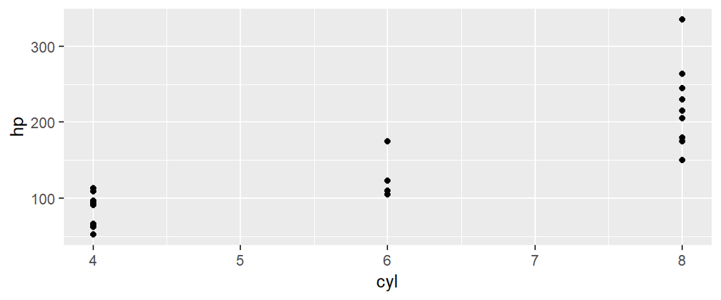

```r
# Execute the following command
ggplot(mtcars, aes(x = cyl, y = hp)) +
  geom_point()
```

Here, cyl is treated as a numerical variable. Now, we will treat **cyl** as factor variable and see what difference it makes.

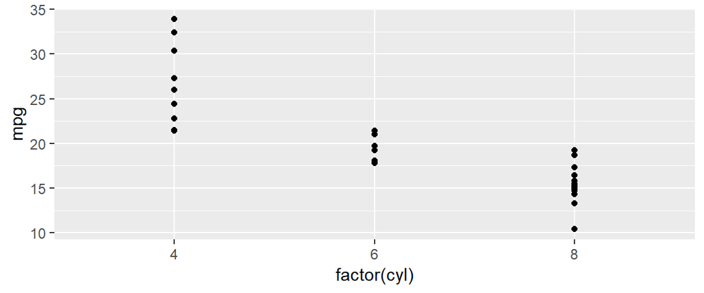

```r
# To treat cyl as a factor
ggplot(mtcars, aes(x = factor(cyl), y = mpg)) +
  geom_point()
```